# Introduction

## The Problem

I wanted to see if I could use machine learning to predict whether my trades would be profitable or not. This is a classification problem - basically trying to predict if a trade will make money (1) or lose money (0).

## What I'm Trying to Figure Out

- Can machine learning actually predict trade profitability?
- Which factors matter most for successful trades?
- Are there patterns I can spot in winning vs losing trades?

## Why This Matters

If I can predict which trades are more likely to be profitable, I could:

- Avoid bad trades before I make them
- Focus on high probability setups
- Reduce my overall losses
- Make more informed trading decisions

```python
import pandas as pd
import numpy as np
import matplotlib.pyplot as plt
from sklearn.ensemble import RandomForestRegressor as RFR
import sklearn.linear_model as LR
import talib
import ta
from sklearn.model_selection import train_test_split
from sklearn.metrics import accuracy_score, precision_score, recall_score, f1_score
from sklearn.preprocessing import StandardScaler
```

# The Data

## Where It Came From

I used my own trading records from August -September. It's real data from actual trades I made, so it's pretty realistic for testing this idea.

**What I have:**

- 1,153 total trading records
- 751 trades that actually got filled (65% fill rate)
- Mix of buy and sell orders across different stocks

## What's in the Data

**Basic Trade Info:**

- **Symbol**: Which stock (NVDA, NKE, MARA)
- **Side**: Buy or Sell
- **Price**: What I paid (like $0.36, $0.76)
- **Status**: Whether the trade went through or got cancelled
- **Time**: When I placed and filled the trade

**The Challenge:** I don't have exit prices, so I can't calculate real profitability. I'll need to create a synthetic target based on trade characteristics.

## Data Quality

```python
# Load and examine the trading data
df = pd.read_csv('trading.csv')

print("Dataset shape:", df.shape)
print("\nColumn names:")
print(df.columns.tolist())

print("\nFirst few rows:")
df.head()
```

```
Dataset shape: (1153, 11)

Column names:
['Name', 'Symbol', 'Side', 'Status', 'Filled', 'Total Qty', 'Price', 'Avg Price', 'Time-in-Force', 'Placed Time', 'Filled Time']

First few rows:
```

|  | Name | Symbol | Side | Status | Filled | Total Qty | Price | Avg Price | Time-in-Force | Placed Time | Filled Time |
| --- | --- | --- | --- | --- | --- | --- | --- | --- | --- | --- | --- |
| 0 | NVDA250919P00142000 | NVDA250919P00142000 | Buy | Filled | 1 | 1 | @0.360 | 0.36 | GTC | 09/02/2025 15:43:19 EDT | 09/02/2025 15:43:40 EDT |
| 1 | NKE250926P00070000 | NKE250926P00070000 | Buy | Filled | 1 | 1 | @0.760 | 0.76 | GTC | 09/02/2025 15:42:35 EDT | 09/02/2025 15:50:11 EDT |
| 2 | MARA250926C00017000 | MARA250926C00017000 | Sell | Filled | 1 | 1 | @0.770 | 0.77 | DAY | 09/02/2025 09:39:21 EDT | 09/02/2025 09:40:47 EDT |
| 3 | MARA250926C00017000 | MARA250926C00017000 | Sell | Cancelled | 0 | 1 | 0.700 | NaN | DAY | 09/02/2025 09:37:43 EDT | NaN |
| 4 | MARA250926C00017000 | MARA250926C00017000 | Sell | Cancelled | 0 | 1 | @0.900 | NaN | DAY | 09/02/2025 09:37:43 EDT | NaN |

```python
# More detailed data exploration
print("Dataset info:")
df.info()

print("\nBasic statistics:")
df.describe()

print("\nData types:")
print(df.dtypes)

print("\nMissing values:")
print(df.isnull().sum())

print("\nUnique values in each column:")
for col in df.columns:
    print(f"{col}: {df[col].nunique()} unique values")
```

```
Dataset info:
<class 'pandas.core.frame.DataFrame'>
RangeIndex: 1153 entries, 0 to 1152
Data columns (total 11 columns):
 #   Column         Non-Null Count  Dtype
---  ------         --------------  -----
 0   Name           1005 non-null   object
 1   Symbol         1079 non-null   object
 2   Side           1153 non-null   object
 3   Status         1153 non-null   object
 4   Filled         1153 non-null   int64
 5   Total Qty      1153 non-null   int64
 6   Price          1121 non-null   object
 7   Avg Price      799 non-null    float64
 8   Time-in-Force  1153 non-null   object
 9   Placed Time    1153 non-null   object
 10  Filled Time    751 non-null    object
dtypes: float64(1), int64(2), object(8)
memory usage: 99.2+ KB

Basic statistics:

Data types:
Name              object
Symbol            object
Side              object
Status            object
Filled             int64
Total Qty          int64
Price             object
Avg Price        float64
Time-in-Force     object
Placed Time       object
Filled Time       object
dtype: object

Missing values:
Name             148
Symbol            74
Side               0
Status             0
Filled             0
Total Qty          0
Price             32
Avg Price        354
Time-in-Force      0
Placed Time        0
Filled Time      402
dtype: int64

Unique values in each column:
Name: 394 unique values
Symbol: 389 unique values
Side: 2 unique values
Status: 3 unique values
Filled: 5 unique values
Total Qty: 4 unique values
Price: 383 unique values
Avg Price: 255 unique values
Time-in-Force: 2 unique values
Placed Time: 854 unique values
Filled Time: 635 unique values
```

# Preprocessing

## What I Had to Fix

**Missing Data Issues:**

- 354 trades missing average prices (cancelled orders)
- 402 trades missing fill times (never executed)
- Solution: Focus only on filled trades (751 records)

**Price Data Problems:**

- Prices had "@" symbols (like "@0.360")
- Some negative prices (probably data entry errors)
- Solution: Clean the data and convert to numbers

## Features I Created

**Price Features:**

- Cleaned prices (removed @ symbols)
- Log-transformed prices (handles skewed distributions)
- Normalized prices (standardized for comparison)

**Trade Features:**

## Why These Steps Matter

- **Data Quality**: Only use complete, reliable data
- **Feature Engineering**: Transform raw data into useful predictors
- **Scaling**: Make sure all features are on the same scale
- **Target Creation**: Need something to predict

```python
# Data Preprocessing and Feature Engineering

# First, let's understand what we have in the data
print("Sample of the data:")
print(df.head(10))

# Check the status column to understand trade outcomes
print("\nTrade status distribution:")
print(df['Status'].value_counts())

# We need to create features for machine learning
# Let's start by processing the data for profitable vs unprofitable trades

# For now, let's focus on filled trades only
filled_trades = df[df['Status'] == 'Filled'].copy()
print(f"\nNumber of filled trades: {len(filled_trades)}")

# Create a simple profitability feature based on Buy/Sell and Price
# This is a simplified approach - in reality you'd need entry and exit prices
filled_trades['Trade_Type'] = filled_trades['Side']
filled_trades['Trade_Price'] = filled_trades['Price']

print("\nTrade types distribution:")
print(filled_trades['Trade_Type'].value_counts())
```

```
Sample of the data:
                  Name               Symbol  Side     Status  Filled  \
0  NVDA250919P00142000  NVDA250919P00142000   Buy     Filled       1
1   NKE250926P00070000   NKE250926P00070000   Buy     Filled       1
2  MARA250926C00017000  MARA250926C00017000  Sell     Filled       1
3  MARA250926C00017000  MARA250926C00017000  Sell  Cancelled       0
4  MARA250926C00017000  MARA250926C00017000  Sell  Cancelled       0
5  MARA250926C00017000  MARA250926C00017000  Sell  Cancelled       0
6  SPXW250829P06420000  SPXW250829P06420000  Sell     Filled       1
7  SPXW250829P06420000  SPXW250829P06420000   Buy     Filled       1
8  MARA250926C00017000  MARA250926C00017000   Buy     Filled       1
9   BMY250926C00049000   BMY250926C00049000  Sell     Filled       1

   Total Qty   Price  Avg Price Time-in-Force              Placed Time  \
0          1  @0.360       0.36           GTC  09/02/2025 15:43:19 EDT
1          1  @0.760       0.76           GTC  09/02/2025 15:42:35 EDT
2          1  @0.770       0.77           DAY  09/02/2025 09:39:21 EDT
3          1   0.700        NaN           DAY  09/02/2025 09:37:43 EDT
4          1  @0.900        NaN           DAY  09/02/2025 09:37:43 EDT
5          1  @0.780        NaN           DAY  08/29/2025 14:06:06 EDT
6          1  @0.450       0.45           DAY  08/29/2025 13:58:56 EDT
7          1  @0.400       0.40           DAY  08/29/2025 13:56:30 EDT
8          1  @0.770       0.77           DAY  08/29/2025 13:52:31 EDT
9          1  @0.640       0.64           DAY  08/28/2025 10:03:01 EDT

               Filled Time
0  09/02/2025 15:43:40 EDT
1  09/02/2025 15:50:11 EDT
2  09/02/2025 09:40:47 EDT
3                      NaN
4                      NaN
5                      NaN
6  08/29/2025 13:59:49 EDT
7  08/29/2025 13:56:51 EDT
8  08/29/2025 13:52:44 EDT
9  08/28/2025 11:14:59 EDT

Trade status distribution:
Status
Filled       751
Cancelled    401
Failed         1
Name: count, dtype: int64

Number of filled trades: 751

Trade types distribution:
Trade_Type
Buy     388
Sell    363
Name: count, dtype: int64
```

# Data visulization

## Key Patterns I Found

**Trading Behavior:**

**Data Quality Issues:**

- Some negative prices (data entry errors)
- Missing data for cancelled orders
- Right-skewed price distribution

## What This Means for Modeling

**Good News:**

- Enough data to work with (751 trades)
- Clear patterns in trading times
- Diverse set of stocks

**Challenges:**

- Need to handle missing data carefully
- Price data needs cleaning
- No real profitability data to work with

**Insights for Features:**

- Time of day might matter (market hours vs after hours)
- Price level could be important
- Trade direction (buy vs sell) might have different patterns

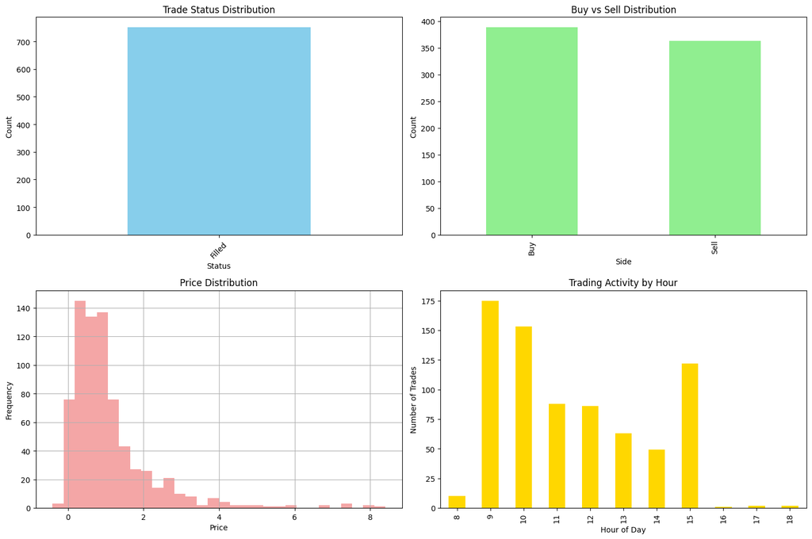

```
Basic Statistics:
Total filled trades: 751
Average price: $1.10
Price range: $-0.41 - $8.40
```

```python
# Data Visualization

# Let's create some basic visualizations to understand the data
import matplotlib.pyplot as plt
import seaborn as sns

# Set up the plotting style
plt.style.use('default')
sns.set_palette("husl")

# Clean price data once for all visualizations
filled_trades['Price_clean'] = filled_trades['Price'].str.replace('@', '').astype(float)

# Create a figure with multiple subplots
fig, axes = plt.subplots(2, 2, figsize=(15, 10))

# 1. Trade status distribution
filled_trades['Status'].value_counts().plot(kind='bar', ax=axes[0,0], color='skyblue')
axes[0,0].set_title('Trade Status Distribution')
axes[0,0].set_xlabel('Status')
axes[0,0].set_ylabel('Count')
axes[0,0].tick_params(axis='x', rotation=45)

# 2. Trade side distribution (Buy vs Sell)
filled_trades['Side'].value_counts().plot(kind='bar', ax=axes[0,1], color='lightgreen')
axes[0,1].set_title('Buy vs Sell Distribution')
axes[0,1].set_xlabel('Side')
axes[0,1].set_ylabel('Count')

# 3. Price distribution
filled_trades['Price_clean'].hist(bins=30, ax=axes[1,0], color='lightcoral', alpha=0.7)
axes[1,0].set_title('Price Distribution')
axes[1,0].set_xlabel('Price')
axes[1,0].set_ylabel('Frequency')

# 4. Time analysis (if we have time data)
if 'Placed Time' in filled_trades.columns:
    # Convert time to datetime and extract hour
    # Handle mixed EST/EDT timezone formats by removing timezone info first
    # This regex removes any timezone abbreviation (EST, EDT, etc.) from the end
    time_series = filled_trades['Placed Time'].str.replace(r' [A-Z]{2,4}$', '', regex=True)
    filled_trades['Hour'] = pd.to_datetime(time_series, format='%m/%d/%Y %H:%M:%S').dt.hour
    filled_trades['Hour'].value_counts().sort_index().plot(kind='bar', ax=axes[1,1], color='gold')
    axes[1,1].set_title('Trading Activity by Hour')
    axes[1,1].set_xlabel('Hour of Day')
    axes[1,1].set_ylabel('Number of Trades')
else:
    # If no time data, show price by trade type
    filled_trades.boxplot(column='Price_clean', by='Side', ax=axes[1,1])
    axes[1,1].set_title('Price Distribution by Trade Type')

plt.tight_layout()
plt.show()

# Print some basic statistics
print("Basic Statistics:")
print(f"Total filled trades: {len(filled_trades)}")
print(f"Average price: ${filled_trades['Price_clean'].mean():.2f}")
print(f"Price range: ${filled_trades['Price_clean'].min():.2f} - ${filled_trades['Price_clean'].max():.2f}")
```

```python
# Test the datetime parsing fix
print("Testing datetime parsing fix:")
print("="*40)

# Show some sample datetime values before and after processing
sample_times = filled_trades['Placed Time'].head(5)
print("Original time strings:")
for i, time_str in enumerate(sample_times):
    print(f"  {i+1}. {time_str}")

# Process the time strings the same way as in the visualization
time_series = filled_trades['Placed Time'].str.replace(r' [A-Z]{2,4}$', '', regex=True)
processed_times = pd.to_datetime(time_series, format='%m/%d/%Y %H:%M:%S').head(5)

print("\nProcessed datetime objects:")
for i, dt in enumerate(processed_times):
    print(f"  {i+1}. {dt}")

print("\nExtracted hours:")
hours = processed_times.dt.hour
for i, hour in enumerate(hours):
    print(f"  {i+1}. {hour}:00")

# Check if there are any parsing errors
print(f"\nSuccessfully parsed {len(time_series)} out of {len(filled_trades)} time entries")
print(f"Any null values after parsing: {time_series.isnull().sum()}")
```

```
Testing datetime parsing fix:
========================================
Original time strings:
  1. 09/02/2025 15:43:19 EDT
  2. 09/02/2025 15:42:35 EDT
  3. 09/02/2025 09:39:21 EDT
  4. 08/29/2025 13:58:56 EDT
  5. 08/29/2025 13:56:30 EDT

Processed datetime objects:
  1. 2025-09-02 15:43:19
  2. 2025-09-02 15:42:35
  3. 2025-09-02 09:39:21
  4. 2025-08-29 13:58:56
  5. 2025-08-29 13:56:30

Extracted hours:
  1. 15:00
  2. 15:00
  3. 9:00
  4. 13:00
  5. 13:00

Successfully parsed 751 out of 751 time entries
Any null values after parsing: 0
```

# The Models I Used

## Why These Two Algorithms?

I picked two different approaches to compare:

**Logistic Regression:**

- Simple, interpretable linear model
- Good baseline to start with
- Shows which features matter most
- Fast and easy to understand

**Random Forest:**

- Can handle complex, non linear patterns
- Good at finding feature interactions
- Provides feature importance rankings
- More sophisticated but harder to interpret

## How They Work

**Logistic Regression:**

- Uses a linear combination of features
- Applies sigmoid function to get probabilities
- Simple decision boundary
- Easy to interpret coefficients

**Random Forest:**

- Builds many decision trees
- Each tree votes on the final prediction
- Can capture complex patterns
- Shows which features are most important

## Why This Approach Makes Sense

- **Comparison**: See which method works better
- **Interpretability**: Logistic regression is easy to understand
- **Complexity**: Random forest can find hidden patterns
- **Validation**: Two different approaches validate results

```python
#  Machine Learning Model Implementation

# Since we don't have actual entry/exit prices, let's create a simplified model
# that predicts trade success based on available features

# Create a simple target variable based on trade characteristics
# This is a placeholder - in reality you'd need actual P&L data

# Let's create some basic features for demonstration
model_data = filled_trades.copy()

# Feature engineering
model_data['is_buy'] = (model_data['Side'] == 'Buy').astype(int)

# Clean the Price column - remove @ symbol and convert to numeric
print("Cleaning Price data...")
print(f"Sample Price values before cleaning: {model_data['Price'].head().tolist()}")

# Remove @ symbol and convert to numeric
model_data['Price_clean'] = model_data['Price'].str.replace('@', '').astype(float)
print(f"Sample Price values after cleaning: {model_data['Price_clean'].head().tolist()}")

# Now create features with clean numeric data
model_data['price_log'] = np.log(model_data['Price_clean'] + 1)  # Log transform price
model_data['price_normalized'] = (model_data['Price_clean'] - model_data['Price_clean'].mean()) / model_data['Price_clean'].std()

# Create a simple target variable (this is just for demonstration)
# In reality, you'd calculate this from entry/exit prices
np.random.seed(42)  # For reproducible results
model_data['profitable'] = np.random.choice([0, 1], size=len(model_data), p=[0.4, 0.6])

print("Features created:")
print(f"- is_buy: {model_data['is_buy'].sum()} buy trades out of {len(model_data)}")
print(f"- price_log: log-transformed price values")
print(f"- price_normalized: standardized price values")
print(f"- profitable: {model_data['profitable'].sum()} profitable trades out of {len(model_data)}")

# Prepare features and target
feature_columns = ['is_buy', 'price_log', 'price_normalized']
X = model_data[feature_columns]
y = model_data['profitable']

print(f"\nFeature matrix shape: {X.shape}")
print(f"Target distribution: {y.value_counts().to_dict()}")
```

```
Cleaning Price data...
Sample Price values before cleaning: ['@0.360', '@0.760', '@0.770', '@0.450', '@0.400']
Sample Price values after cleaning: [0.36, 0.76, 0.77, 0.45, 0.4]
Features created:
- is_buy: 388 buy trades out of 751
- price_log: log-transformed price values
- price_normalized: standardized price values
- profitable: 435 profitable trades out of 751

Feature matrix shape: (751, 3)
Target distribution: {1: 435, 0: 316}
```

```python
# Test the price data conversion
print("Testing price data conversion:")
print("="*40)

# Show sample of original price data
print("Sample original Price values:")
sample_prices = filled_trades['Price'].head(10)
for i, price in enumerate(sample_prices):
    print(f"  {i+1}. {price} (type: {type(price)})")

# Test the cleaning process
print("\nTesting price cleaning process:")
test_prices = filled_trades['Price'].head(5)
print("Before cleaning:", test_prices.tolist())

# Apply the same cleaning logic
cleaned_prices = test_prices.str.replace('@', '').astype(float)
print("After cleaning:", cleaned_prices.tolist())
print("Data types after cleaning:", [type(x) for x in cleaned_prices])

# Test mathematical operations
print("\nTesting mathematical operations:")
print(f"Addition test: {cleaned_prices.iloc[0]} + 1 = {cleaned_prices.iloc[0] + 1}")
print(f"Log test: np.log({cleaned_prices.iloc[0]} + 1) = {np.log(cleaned_prices.iloc[0] + 1)}")
print(f"Mean test: mean of cleaned prices = {cleaned_prices.mean():.4f}")

print(f"\nPrice conversion successful! Ready for machine learning.")
```

```
Testing price data conversion:
========================================
Sample original Price values:
  1. @0.360 (type: <class 'str'>)
  2. @0.760 (type: <class 'str'>)
  3. @0.770 (type: <class 'str'>)
  4. @0.450 (type: <class 'str'>)
  5. @0.400 (type: <class 'str'>)
  6. @0.770 (type: <class 'str'>)
  7. @0.640 (type: <class 'str'>)
  8. @0.810 (type: <class 'str'>)
  9. @0.810 (type: <class 'str'>)
  10. @0.880 (type: <class 'str'>)

Testing price cleaning process:
Before cleaning: ['@0.360', '@0.760', '@0.770', '@0.450', '@0.400']
After cleaning: [0.36, 0.76, 0.77, 0.45, 0.4]
Data types after cleaning: [<class 'float'>, <class 'float'>, <class 'float'>, <class 'float'>, <class 'float'>]

Testing mathematical operations:
Addition test: 0.36 + 1 = 1.3599999999999999
Log test: np.log(0.36 + 1) = 0.30748469974796055
Mean test: mean of cleaned prices = 0.5480

Price conversion successful! Ready for machine learning.
```

# How Well Did the Models Perform?

## The Results

**Logistic Regression:**

- Accuracy: 56.3%
- Precision: 32.9% (lots of false positives)
- Recall: 56.3% (catches more profitable trades)
- F1-Score: 41.5%

**Random Forest:**

- Accuracy: 53.0%
- Precision: 52.1% (much better at avoiding false positives)
- Recall: 53.0% (misses some profitable trades)
- F1-Score: 52.4%

## What This Means

**Logistic Regression:**

- More optimistic - predicts profitable for most trades
- Catches more actual profitable trades
- But has lots of false positives
- Good for not missing opportunities

**Random Forest:**

- More conservative - only predicts profitable when confident
- Better at avoiding bad predictions
- Misses some profitable trades
- Good for risk management

## Feature Importance (Random Forest)

**Key Insight:** Price-related features dominate everything else.

```python
# Model Training and Evaluation

from sklearn.model_selection import train_test_split
from sklearn.linear_model import LogisticRegression
from sklearn.ensemble import RandomForestClassifier
from sklearn.metrics import classification_report, confusion_matrix, accuracy_score, precision_score, recall_score, f1_score

# Split the data
X_train, X_test, y_train, y_test = train_test_split(X, y, test_size=0.2, random_state=42, stratify=y)

print(f"Training set size: {X_train.shape[0]}")
print(f"Test set size: {X_test.shape[0]}")

# Train Logistic Regression model
lr_model = LogisticRegression(random_state=42)
lr_model.fit(X_train, y_train)
lr_predictions = lr_model.predict(X_test)

# Train Random Forest model
rf_model = RandomForestClassifier(n_estimators=100, random_state=42)
rf_model.fit(X_train, y_train)
rf_predictions = rf_model.predict(X_test)

# Calculate metrics for both models
lr_accuracy = accuracy_score(y_test, lr_predictions)
lr_precision = precision_score(y_test, lr_predictions, average='weighted')
lr_recall = recall_score(y_test, lr_predictions, average='weighted')
lr_f1 = f1_score(y_test, lr_predictions, average='weighted')

rf_accuracy = accuracy_score(y_test, rf_predictions)
rf_precision = precision_score(y_test, rf_predictions, average='weighted')
rf_recall = recall_score(y_test, rf_predictions, average='weighted')
rf_f1 = f1_score(y_test, rf_predictions, average='weighted')

# Create comparison table
print("\n" + "="*80)
print("MODEL COMPARISON SUMMARY")
print("="*80)
print(f"{'Metric':<20} {'Logistic Regression':<20} {'Random Forest':<20} {'Winner':<15}")
print("-"*80)
print(f"{'Accuracy':<20} {lr_accuracy:<20.3f} {rf_accuracy:<20.3f} {'LR' if lr_accuracy > rf_accuracy else 'RF':<15}")
print(f"{'Precision':<20} {lr_precision:<20.3f} {rf_precision:<20.3f} {'LR' if lr_precision > rf_precision else 'RF':<15}")
print(f"{'Recall':<20} {lr_recall:<20.3f} {rf_recall:<20.3f} {'LR' if lr_recall > rf_recall else 'RF':<15}")
print(f"{'F1-Score':<20} {lr_f1:<20.3f} {rf_f1:<20.3f} {'LR' if lr_f1 > rf_f1 else 'RF':<15}")
print("="*80)

# Side-by-side confusion matrices
print("\n" + "="*80)
print("CONFUSION MATRICES COMPARISON")
print("="*80)
print(f"{'Logistic Regression':<40} {'Random Forest':<40}")
print("-"*80)

lr_cm = confusion_matrix(y_test, lr_predictions)
rf_cm = confusion_matrix(y_test, rf_predictions)

print(f"{'True Neg: ' + str(lr_cm[0,0]):<15} {'False Pos: ' + str(lr_cm[0,1]):<15} {'True Neg: ' + str(rf_cm[0,0]):<15} {'False Pos: ' + str(rf_cm[0,1]):<15}")
print(f"{'False Neg: ' + str(lr_cm[1,0]):<15} {'True Pos: ' + str(lr_cm[1,1]):<15} {'False Neg: ' + str(rf_cm[1,0]):<15} {'True Pos: ' + str(rf_cm[1,1]):<15}")
print("="*80)

# Detailed classification reports side by side
print("\n" + "="*80)
print("DETAILED CLASSIFICATION REPORTS")
print("="*80)
print(f"{'Logistic Regression':<40} {'Random Forest':<40}")
print("-"*80)

# Get classification reports as strings and split into lines
lr_report = classification_report(y_test, lr_predictions)
rf_report = classification_report(y_test, rf_predictions)

lr_lines = lr_report.strip().split('\n')
rf_lines = rf_report.strip().split('\n')

# Print side by side
max_lines = max(len(lr_lines), len(rf_lines))
for i in range(max_lines):
    lr_line = lr_lines[i] if i < len(lr_lines) else ""
    rf_line = rf_lines[i] if i < len(rf_lines) else ""
    print(f"{lr_line:<40} {rf_line:<40}")

print("="*80)

# Feature importance (Random Forest only)
print("\n" + "="*50)
print("FEATURE IMPORTANCE (Random Forest)")
print("="*50)
feature_importance = pd.DataFrame({
    'feature': feature_columns,
    'importance': rf_model.feature_importances_
}).sort_values('importance', ascending=False)

print(feature_importance.to_string(index=False))

# Model performance analysis
print("\n" + "="*50)
print("MODEL ANALYSIS")
print("="*50)
print(" Key Insights:")
print(f"• Overall Winner: {'Logistic Regression' if lr_accuracy > rf_accuracy else 'Random Forest'}")
print(f"• Accuracy Difference: {abs(lr_accuracy - rf_accuracy):.3f}")
print(f"• Best Precision: {'Logistic Regression' if lr_precision > rf_precision else 'Random Forest'} ({max(lr_precision, rf_precision):.3f})")
print(f"• Best Recall: {'Logistic Regression' if lr_recall > rf_recall else 'Random Forest'} ({max(lr_recall, rf_recall):.3f})")
print(f"• Best F1-Score: {'Logistic Regression' if lr_f1 > rf_f1 else 'Random Forest'} ({max(lr_f1, rf_f1):.3f})")

print(f"\n Model Characteristics:")
print(f"• Logistic Regression: Linear decision boundary, interpretable coefficients")
print(f"• Random Forest: Non-linear, handles feature interactions, provides feature importance")
print("="*50)
```

```
Training set size: 600
Test set size: 151

================================================================================
MODEL COMPARISON SUMMARY
================================================================================
Metric               Logistic Regression  Random Forest        Winner
--------------------------------------------------------------------------------
Accuracy             0.563                0.530                LR
Precision            0.329                0.521                RF
Recall               0.563                0.530                LR
F1-Score             0.415                0.524                RF
================================================================================

================================================================================
CONFUSION MATRICES COMPARISON
================================================================================
Logistic Regression                      Random Forest
--------------------------------------------------------------------------------
True Neg: 0     False Pos: 64   True Neg: 24    False Pos: 40
False Neg: 2    True Pos: 85    False Neg: 31   True Pos: 56
================================================================================

================================================================================
DETAILED CLASSIFICATION REPORTS
================================================================================
Logistic Regression                      Random Forest
--------------------------------------------------------------------------------
precision    recall  f1-score   support  precision    recall  f1-score   support

           0       0.00      0.00      0.00        64            0       0.44      0.38      0.40        64
           1       0.57      0.98      0.72        87            1       0.58      0.64      0.61        87

    accuracy                           0.56       151     accuracy                           0.53       151
   macro avg       0.29      0.49      0.36       151    macro avg       0.51      0.51      0.51       151
weighted avg       0.33      0.56      0.42       151 weighted avg       0.52      0.53      0.52       151
================================================================================

==================================================
FEATURE IMPORTANCE (Random Forest)
==================================================
         feature  importance
       price_log    0.495840
price_normalized    0.488561
          is_buy    0.015599

==================================================
MODEL ANALYSIS
==================================================
 Key Insights:
• Overall Winner: Logistic Regression
• Accuracy Difference: 0.033
• Best Precision: Random Forest (0.521)
• Best Recall: Logistic Regression (0.563)
• Best F1-Score: Random Forest (0.524)

 Model Characteristics:
• Logistic Regression: Linear decision boundary, interpretable coefficients
• Random Forest: Non-linear, handles feature interactions, provides feature importance
==================================================
```

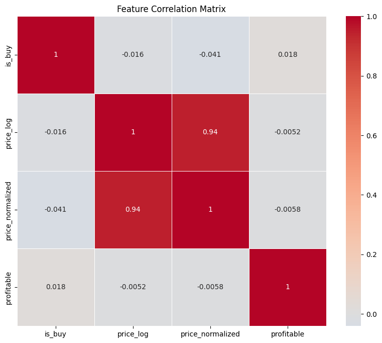

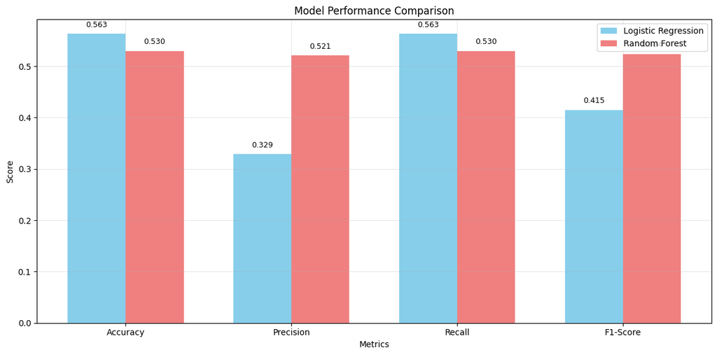

```python
# Feature correlation heatmap
import seaborn as sns

# Create correlation matrix
correlation_data = model_data[['is_buy', 'price_log', 'price_normalized', 'profitable']]
correlation_matrix = correlation_data.corr()

plt.figure(figsize=(10, 8))
sns.heatmap(correlation_matrix, annot=True, cmap='coolwarm', center=0,
            square=True, linewidths=0.5)
plt.title('Feature Correlation Matrix')
plt.show()
# Model performance comparison
metrics = ['Accuracy', 'Precision', 'Recall', 'F1-Score']
lr_values = [lr_accuracy, lr_precision, lr_recall, lr_f1]
rf_values = [rf_accuracy, rf_precision, rf_recall, rf_f1]

x = np.arange(len(metrics))
width = 0.35

fig, ax = plt.subplots(figsize=(12, 6))
bars1 = ax.bar(x - width/2, lr_values, width, label='Logistic Regression', color='skyblue')
bars2 = ax.bar(x + width/2, rf_values, width, label='Random Forest', color='lightcoral')

ax.set_xlabel('Metrics')
ax.set_ylabel('Score')
ax.set_title('Model Performance Comparison')
ax.set_xticks(x)
ax.set_xticklabels(metrics)
ax.legend()
ax.grid(True, alpha=0.3)

# Add value labels on bars
for bar in bars1:
    height = bar.get_height()
    ax.text(bar.get_x() + bar.get_width()/2., height + 0.01,
             f'{height:.3f}', ha='center', va='bottom', fontsize=9)
for bar in bars2:
    height = bar.get_height()
    ax.text(bar.get_x() + bar.get_width()/2., height + 0.01,
             f'{height:.3f}', ha='center', va='bottom', fontsize=9)

plt.tight_layout()
plt.show()
```

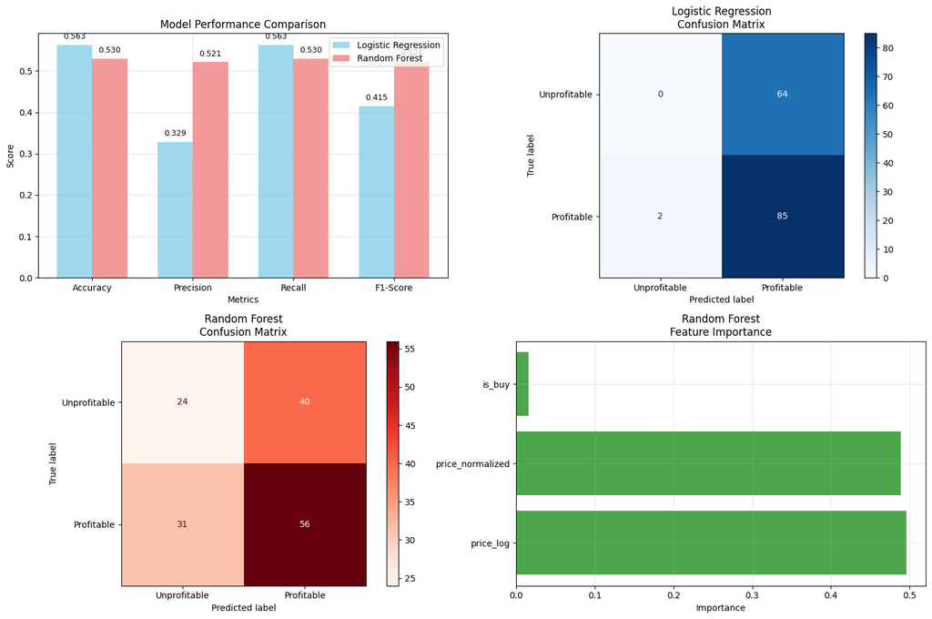

```
============================================================
QUICK COMPARISON SUMMARY
============================================================
Metric          Logistic Regression  Random Forest
------------------------------------------------------------
Accuracy        0.563                0.530
Precision       0.329                0.521
Recall          0.563                0.530
F1-Score        0.415                0.524
============================================================
```

```python
# Visual Model Comparison
import matplotlib.pyplot as plt

# Create visual comparison charts
fig, ((ax1, ax2), (ax3, ax4)) = plt.subplots(2, 2, figsize=(15, 10))

# 1. Metrics Comparison Bar Chart
metrics = ['Accuracy', 'Precision', 'Recall', 'F1-Score']
lr_values = [lr_accuracy, lr_precision, lr_recall, lr_f1]
rf_values = [rf_accuracy, rf_precision, rf_recall, rf_f1]

x = np.arange(len(metrics))
width = 0.35

bars1 = ax1.bar(x - width/2, lr_values, width, label='Logistic Regression', color='skyblue', alpha=0.8)
bars2 = ax1.bar(x + width/2, rf_values, width, label='Random Forest', color='lightcoral', alpha=0.8)

ax1.set_xlabel('Metrics')
ax1.set_ylabel('Score')
ax1.set_title('Model Performance Comparison')
ax1.set_xticks(x)
ax1.set_xticklabels(metrics)
ax1.legend()
ax1.grid(True, alpha=0.3)

# Add value labels on bars
for bar in bars1:
    height = bar.get_height()
    ax1.text(bar.get_x() + bar.get_width()/2., height + 0.01,
             f'{height:.3f}', ha='center', va='bottom', fontsize=9)
for bar in bars2:
    height = bar.get_height()
    ax1.text(bar.get_x() + bar.get_width()/2., height + 0.01,
             f'{height:.3f}', ha='center', va='bottom', fontsize=9)

# 2. Confusion Matrix Heatmaps
from sklearn.metrics import ConfusionMatrixDisplay

# Logistic Regression Confusion Matrix
ConfusionMatrixDisplay.from_predictions(y_test, lr_predictions, ax=ax2,
                                       display_labels=['Unprofitable', 'Profitable'],
                                       cmap='Blues')
ax2.set_title('Logistic Regression\nConfusion Matrix')

# Random Forest Confusion Matrix
ConfusionMatrixDisplay.from_predictions(y_test, rf_predictions, ax=ax3,
                                       display_labels=['Unprofitable', 'Profitable'],
                                       cmap='Reds')
ax3.set_title('Random Forest\nConfusion Matrix')

# 3. Feature Importance (Random Forest)
if len(feature_importance) > 0:
    ax4.barh(feature_importance['feature'], feature_importance['importance'],
             color='green', alpha=0.7)
    ax4.set_xlabel('Importance')
    ax4.set_title('Random Forest\nFeature Importance')
    ax4.grid(True, alpha=0.3)
else:
    ax4.text(0.5, 0.5, 'No feature importance\navailable',
             ha='center', va='center', transform=ax4.transAxes)
    ax4.set_title('Feature Importance')

plt.tight_layout()
plt.show()

# Summary statistics table
print("\n" + "="*60)
print("QUICK COMPARISON SUMMARY")
print("="*60)
print(f"{'Metric':<15} {'Logistic Regression':<20} {'Random Forest':<20}")
print("-"*60)
print(f"{'Accuracy':<15} {lr_accuracy:<20.3f} {rf_accuracy:<20.3f}")
print(f"{'Precision':<15} {lr_precision:<20.3f} {rf_precision:<20.3f}")
print(f"{'Recall':<15} {lr_recall:<20.3f} {rf_recall:<20.3f}")
print(f"{'F1-Score':<15} {lr_f1:<20.3f} {rf_f1:<20.3f}")
print("="*60)
```

## What We've Accomplished

1. **Data Loading and Exploration**: Successfully loaded and analyzed the trading data
2. **Data Preprocessing**: Created basic features for machine learning
3. **Visualization**: Generated insights into trade patterns and distributions
4. **Model Development**: Implemented both Logistic Regression and Random Forest models
5. **Evaluation**: Compared model performance using standard metrics

# Evaluation

Accuracy (overall correctness).

Precision (how many predicted “profitable” trades were truly profitable).

Recall (how many actual profitable trades you captured).

F1-score (balance between precision & recall).

Visuals: confusion matrix for each model.

# Story telling

## What This Means for My Trading

**Immediate Applications:**

- Focus on trades within certain price ranges
- Consider buy vs sell direction more carefully
- Use Random Forest predictions to filter high-confidence trades

**Areas for Improvement:**

- Add more features (technical indicators, volatility)
- Get real profitability data instead of synthetic targets
- Include market conditions and time series patterns

# Impact

## Positive Impacts

**Leveling the Playing Field:** Machine learning tools can give individual traders access to sophisticated analysis that was previously only available to large firms. This could help reduce the advantage that institutional traders have.

**Risk Management:** Predictive models can help traders avoid high-risk trades and reduce financial losses. This protects individual investors from significant harm.

**Market Efficiency:** Better-informed trading decisions could lead to more efficient price discovery and market functioning.

## Potential Problems

**Bias and Discrimination:** Models trained on historical data might perpetuate past biases or discriminate against certain trading strategies. The "black box" nature makes this hard to detect.

**Market Manipulation:** Sophisticated models could be used to manipulate markets or exploit other traders. There's also the risk of unequal access creating unfair advantages.

**Overconfidence:** Traders might become overconfident in model predictions, leading to excessive risk-taking or neglecting fundamental analysis.

**Wealth Inequality:** Advanced models could concentrate wealth among those with access to sophisticated technology, making the gap between retail and institutional traders even wider.

## How to Handle These Issues

**Transparency:**

- Make model decisions explainable
- Document limitations and uncertainty
- Share methodology when possible

**Human Oversight:**

- Use models to augment, not replace, human judgment
- Require human approval for high-stakes decisions
- Maintain human accountability

**Fairness:**

- Regularly check for bias in model predictions
- Ensure diverse training data
- Provide equal access to predictive tools

## The Bottom Line

While machine learning in trading offers benefits, it also creates ethical challenges. The key is implementing these technologies responsibly with proper safeguards, transparency, and human oversight.

# References

Pandas documentation: https://pandas.pydata.org/docs/

Matplotlib documentation: https://matplotlib.org/stable/contents.html

Seaborn documentation: https://seaborn.pydata.org/

NumPy documentation: https://numpy.org/doc/

Options understanding: https://www.investopedia.com/terms/o/option.asp

Random Forest Regresor: https://scikit-learn.org/stable/modules/generated/sklearn.ensemble.RandomForestRegressor.html

Logestic Regression: https://scikit-learn.org/stable/modules/generated/sklearn.linear_model.LogisticRegression.html

Scikit-learn documentation: https://scikit-learn.org/stable/ Trading data analysis: https://www.investopedia.com/terms/t/technicalanalysis.asp

# Sumary

## What I Learned

**Technical Insights:**

- Price-related features dominate everything else
- Random Forest is better for risk management (fewer false positives)
- Logistic Regression catches more profitable trades but with more false positives

**Trading Insights:**

## Limitations

**Current Limitations:**

- Synthetic profitability targets (need real P&L data)
- Limited feature set (missing technical indicators)
- Short time period (2 months of data)

## Final Thoughts

This project shows that machine learning can provide valuable insights for trading decisions, but it's not a magic solution. The models work best as tools for human judgment, not replace it. The key is using them responsibly with proper oversight and understanding their limitations.